# Hate in Context

Week 10: Reducing Hate Crime II — Persuasion

Violeta Haas

Department of Political Science

School of Social Sciences and Philosophy

Trinity College Dublin

# This Week

1. Catch-up: Week 9
2. Persuasion
3. Exercise: At the Christmas Table
4. Strategies
5. Synthesis
6. Outlook

# Catch-up: Week 9

## The perfect Experiment

Design a hypothetical (para)social contact experiment to reduce prejudice/discrimination. Imagine unlimited resources (monetary, time, and (wo)manpower).

1

2

3

4

5

**Your task** (groups of 3–4)

- Design a research poster for your experiment.
  1. Title + RQ
  2. Short description (including setting + sample)
  3. Design: treatment, control & randomization
  4. Outcomes (include attitudinal + behavioral)
  5. Are (para)social contact criteria met and how?
- Each group picks one person to pitch (**2 min**).
- Vote on the best Experiment!

## Collect notes (5 min)

**If you were here last week**

1. Collect your notes from the poster.
2. Decide who will pitch (2 minutes).

**If you missed last week**

1. What are internal and external validity in experiments?
2. What does scalability mean for experimental interventions?

Your turn!

## Vote on the best Experiment!

on Blackboard → Week 10 → POU44653 Week 10: Vote on the best Experiment

## Internal / external validity and scalability

### Internal validity

**Definition:** The independent variable (the treatment) truly caused the change in the dependent variable (the outcome), rather than being driven by confounding factors.

1. Within this study, can we trust that the treatment caused the outcome?

### External validity

**Definition:** The causal relationship found in a specific study holds true across different populations, settings, times, or contexts (generalizability).

### Scalability

**Definition:** The intervention, or method can be scaled up to a larger population, a broader region, or another organizational level without losing its effectiveness.

# Persuasion

Why is it so difficult to persuade people?

## Why persuasion fails

Kalla & Broockman (2020) argue that people often resist persuasion because:

1. **Admitting error:** changing one’s mind means accepting that prior views were wrong
2. **Identity protection:** attitudes often affirm valued group memberships (e.g. partisanship). Contrary views threaten that identity (social identity theory), so people defend the attitude to protect the self and their group
3. **Autonomy:** people dislike feeling manipulated, so they counter-argue or dismiss messages

→ **Motivated reasoning:** people are motivated to dismiss evidence and arguments contrary to their views (e.g. Leeper & Slothuus 2014; Miller 1976; Sigelman & Sigelman 1984)

# Exercise: At the Christmas Table

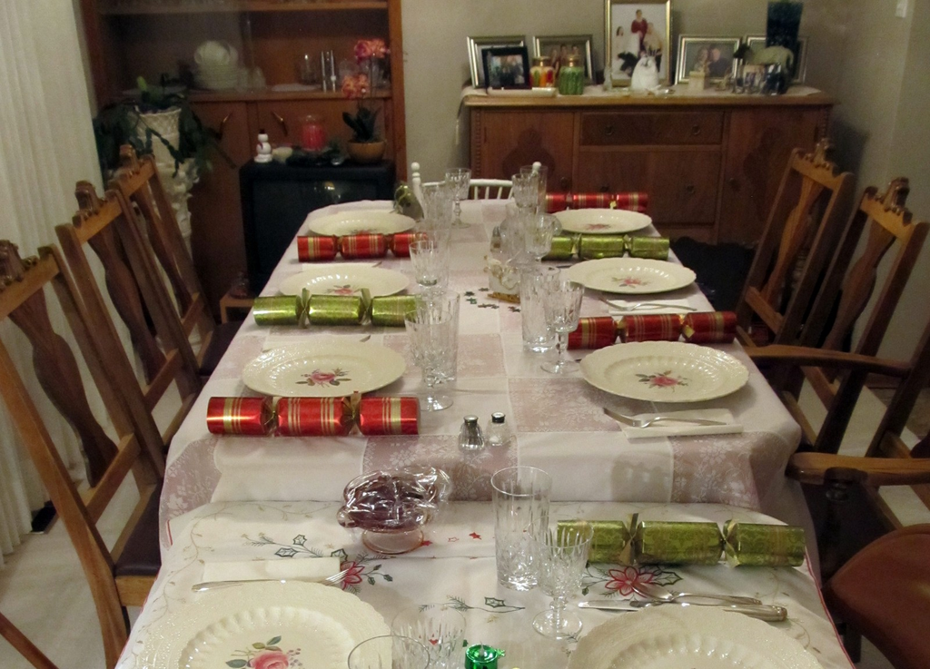

## At the Christmas Table

It’s Christmas time, we all know what that means! Turkey, wine… and Uncle Seán bringing up immigration again. He’s repeatedly expressed anti-immigrant sentiments. This year, you want to have a better conversation than last year and persuade Uncle Seán to rethink his exclusionary attitudes.

[figure not shown]

**Your task** (groups of 3–4, ≈20–25 min)

1. Decide on a strategy from the readings — which ones seemed to work, and why?
2. Open the chatbot (QR, link, or Blackboard) and try that approach with Seán.
3. When you’re finished, click Ask for debrief for your score.
4. Download your conversation.

Rules: max 10 turns; you may restart the chat once.

https://uncle-sean.onrender.com/

Also on Blackboard → Week 10 → Uncle Seán

Which approach did you take and did it work?

# Strategies for Persuasion

## Strategy Overview

### Belief correction

- Arguments alone
- Information-only

### Social sanctioning

- Warning of consequences
- Humor

### Narratives

- Non-judgmental exchange of narratives
- Traditional perspective-taking
- Analogic perspective-taking
- Perspective-getting
- Vicarious perspective-giving
- Empathy-based counterspeech

## Why narratives work

**Narrative persuasion** (Green & Brock 2000; Moyer-Gusè 2008; Slater & Rouner 2002)…

- …feels less manipulative than arguments
- …is harder to counter-argue than explicit claims
- …“immerses” / “transports” people, so they are less critical and more engaged
- …can persuade more than statistical evidence

**If paired with non-judgmental / high-quality listening** (Itzchakov et al. 2017; Cohen et al. 2000)…

- …reduces threat to the self
- …affirmation / respect increases openness to other views
- …creates a “safe space” to acknowledge alternatives
- …can promote self-persuasion: people start to see the other side’s arguments as (partly) their own (Aronson 1999)

## System 2 processing

Dual-process accounts distinguish fast, automatic thinking from slower, effortful thinking (Kahneman, 2011):

### System 1

- Fast, intuitive, automatic
- Relies on heuristics and affect
- Easy default for political judgments

### System 2

- Slow, deliberative, effortful
- Actively weighs reasons and evidence
- Can revise prior attitudes — when engaged

## Belief correction

**Strategy (Kalla & Broockman 2020; Adida et al. 2018):** Leading with facts, statistics, and reasons to correct a mistaken belief (arguments / information alone).

Uncle Seán *cuts into turkey, takes a sip of wine*  
You know, I was reading something the other day about the hospital waiting lists — absolute nightmare now. And half of it, honestly, is just the pressure from… well, people coming in who haven't paid in, haven't they? I mean, I'm not saying don't help folk, but when your own nan's waiting six months for a hip operation while we're processing asylum claims… it doesn't add up, does it?  
*glances up*  
How's your turkey? What do you reckon—you're studying all this stuff at uni now.

You Uncle Seán, the numbers don't actually support that. Asylum seekers are a tiny share of the population, and waiting lists are driven mainly by staffing, funding, and capacity, not asylum claims. Immigrant households also pay taxes and PRSI like everyone else once they're working.

…

## Findings on: Belief correction

**Adida et al. (2018, Fig. 1):** information alone ≈ 0

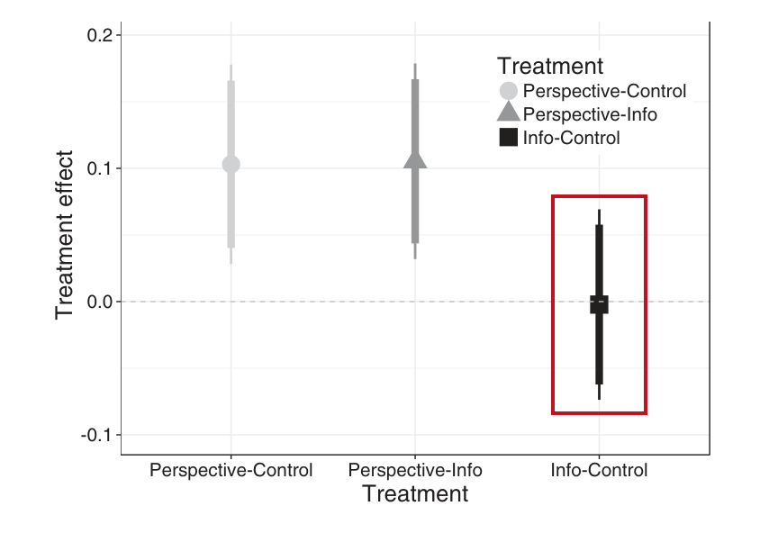

## Findings on: Belief correction

**Kalla & Broockman (2020, Fig. 1):** arguments alone ≈ 0

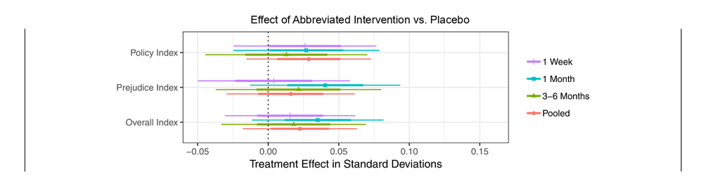

## Warning of consequences

**Strategy (Hangartner et al. 2021):** Raise the social or reputational cost of the exclusionary claim.

Uncle Seán *cuts into turkey, takes a sip of wine*  
You know, I was reading something the other day about the hospital waiting lists — absolute nightmare now. And half of it, honestly, is just the pressure from… well, people coming in who haven't paid in, haven't they? I mean, I'm not saying don't help folk, but when your own nan's waiting six months for a hip operation while we're processing asylum claims… it doesn't add up, does it?  
*glances up*  
How's your turkey? What do you reckon—you're studying all this stuff at uni now.

You Uncle Seán, we've had enough. Nobody at this table agrees with you, and nobody wants to have this fight again over Christmas dinner. If this is how it goes every year, next year we might not invite you.

…

## Findings on: Warning of consequences

**Hangartner et al. (2021, Fig. 2):** warning of consequences ≈ 0

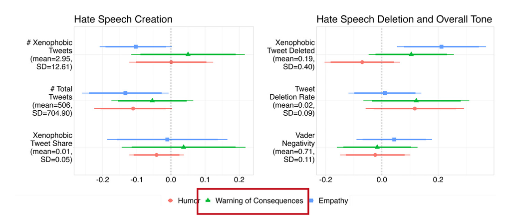

## Humor

**Strategy (Hangartner et al. 2021):** Deflate or ridicule the exclusionary claim with humor.

Uncle Seán *cuts into turkey, takes a sip of wine*  
You know, I was reading something the other day about the hospital waiting lists — absolute nightmare now. And half of it, honestly, is just the pressure from… well, people coming in who haven't paid in, haven't they? I mean, I'm not saying don't help folk, but when your own nan's waiting six months for a hip operation while we're processing asylum claims… it doesn't add up, does it?  
*glances up*  
How's your turkey? What do you reckon—you're studying all this stuff at uni now.

You Ah here we go, the annual Christmas special: "Waiting Lists & The Foreigners", directed by Uncle Seán, runtime ninety minutes, no interval. I'm only slagging, but maybe park the asylum rant until after dessert? The turkey's done nothing wrong.

…

## Findings on: Humor

**Hangartner et al. (2021, Fig. 2):** humor ≈ 0

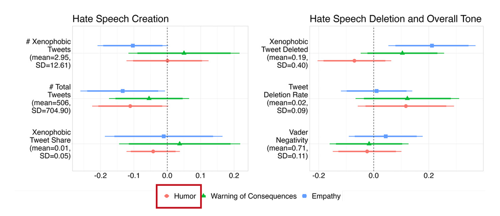

## Non-judgmental exchange of narratives

**Strategy (Kalla & Broockman 2020):** Non-judgmentally exchanging narratives about relevant experiences.

Uncle Seán *cuts into turkey, takes a sip of wine*  
You know, I was reading something the other day about the hospital waiting lists — absolute nightmare now. And half of it, honestly, is just the pressure from… well, people coming in who haven't paid in, haven't they? I mean, I'm not saying don't help folk, but when your own nan's waiting six months for a hip operation while we're processing asylum claims… it doesn't add up, does it?  
*glances up*  
How's your turkey? What do you reckon—you're studying all this stuff at uni now.

You Uncle Seán, I want to understand where you're coming from. Tell me more about what worries you with Nan and the waiting lists. And if you're open to it, I'll share a story I've heard from someone who's been through the asylum process.

…

## Findings on: Non-judgmental exchange

**Kalla & Broockman (2020, Fig. 1):** full intervention (incl. non-judgmental exchange) ↑ inclusion

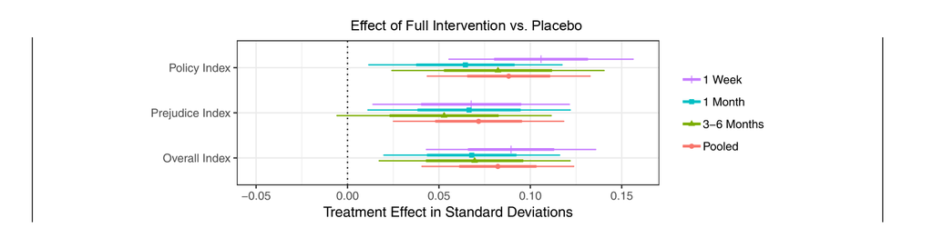

**Kalla & Broockman (2020, Fig. 1):** full vs arguments alone ↑ inclusion

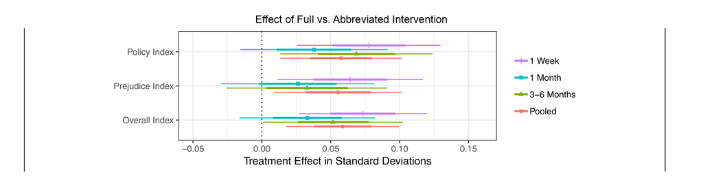

## Traditional perspective-taking

**Strategy (Adida et al. 2018; Kalla & Broockman 2023):** Ask to imagine an experience from the perspective of an outgroup member.

Uncle Seán *cuts into turkey, takes a sip of wine*  
You know, I was reading something the other day about the hospital waiting lists — absolute nightmare now. And half of it, honestly, is just the pressure from… well, people coming in who haven't paid in, haven't they? I mean, I'm not saying don't help folk, but when your own nan's waiting six months for a hip operation while we're processing asylum claims… it doesn't add up, does it?  
*glances up*  
How's your turkey? What do you reckon—you're studying all this stuff at uni now.

You Uncle Seán, can I ask you to try something with me for a second? Not agreeing, just imagining? Imagine you had to leave Ireland overnight with one bag, and you were waiting for a decision on whether you could stay somewhere safe. What would that first week feel like?

…

You Yeah. In that imagined week — what would you most want from the people around you?

…

You I'm asking because when people talk about asylum, we often jump straight to systems and queues instead of considering individuals' stories.

## Findings on: Traditional perspective-taking

**Adida et al. (2018, Fig. 1):** perspective-taking ↑ inclusion

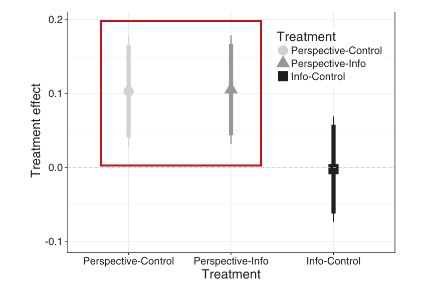

## Findings on: Traditional perspective-taking

**Kalla & Broockman (2023, Fig. 7):** traditional perspective-taking ≈ 0

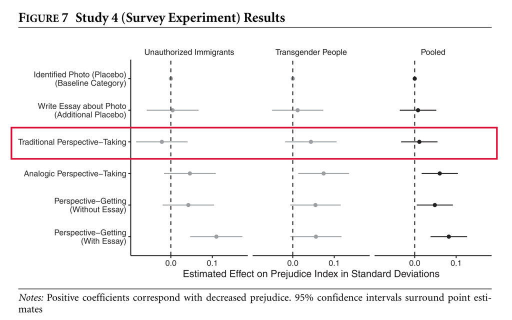

## Analogic perspective-taking

**Strategy (Broockman & Kalla 2016; Kalla & Broockman 2023):** Ask to recall a similar situation from one’s own experience.

Uncle Seán *cuts into turkey, takes a sip of wine*  
You know, I was reading something the other day about the hospital waiting lists — absolute nightmare now. And half of it, honestly, is just the pressure from… well, people coming in who haven't paid in, haven't they? I mean, I'm not saying don't help folk, but when your own nan's waiting six months for a hip operation while we're processing asylum claims… it doesn't add up, does it?  
*glances up*  
How's your turkey? What do you reckon—you're studying all this stuff at uni now.

You Uncle Seán, before we go further into that. Can I ask you something a bit sideways? Has there ever been a time you felt written off or judged by people who didn't really know you?

…

You Yeah. When that happened, what did you want from people? Like, what would have felt fair?

…

You I'm not saying it's the same thing, but when I hear stories from people who came here seeking safety, a lot of what they want sounds close to that: just not to be written off before anyone hears them.

## Findings on: Analogic perspective-taking

**Kalla & Broockman (2023, Fig. 1):** dropping analogic perspective taking still ↑ inclusion

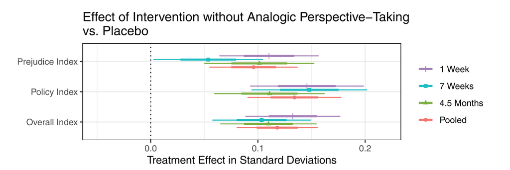

**Kalla & Broockman (2023, Fig. 1):** dropping analogic perspective-taking ≈ full intervention

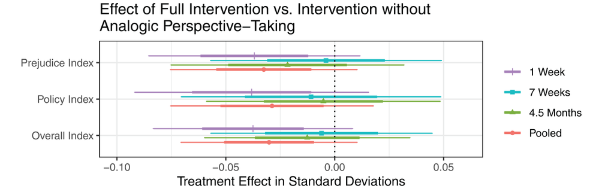

## Findings on: Analogic perspective-taking

**Kalla & Broockman (2023, Fig. 7):** analogic perspective-taking ↑ inclusion

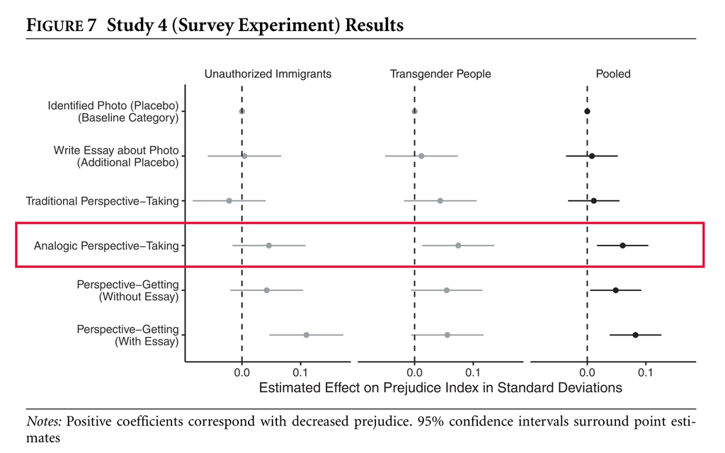

## Perspective-getting

**Strategy (Kalla & Broockman 2020; Kalla & Broockman 2023):** Share a narrative about an outgroup member’s experiences (as in-group or out-group member).

Uncle Seán *cuts into turkey, takes a sip of wine*  
You know, I was reading something the other day about the hospital waiting lists — absolute nightmare now. And half of it, honestly, is just the pressure from… well, people coming in who haven't paid in, haven't they? I mean, I'm not saying don't help folk, but when your own nan's waiting six months for a hip operation while we're processing asylum claims… it doesn't add up, does it?  
*glances up*  
How's your turkey? What do you reckon—you're studying all this stuff at uni now.

You Can I tell you something concrete? A friend of mine, Amira, came here from Syria a few years ago. She said the hardest part wasn't the paperwork, it was people deciding who she was before she'd said a word. She just wanted someone to hear her story first.

…

You She told me about waiting months for a GP appointment while also being blamed in the news for pressure on the health services. She said it made her feel invisible and suspicious at the same time. What she wanted wasn't special treatment, just for people to stop talking about “them” as if she'd never stood in a queue herself.

## Findings on: Perspective-getting

**Kalla & Broockman (2023, Fig. 4):** perspective-getting alone ↑ inclusion

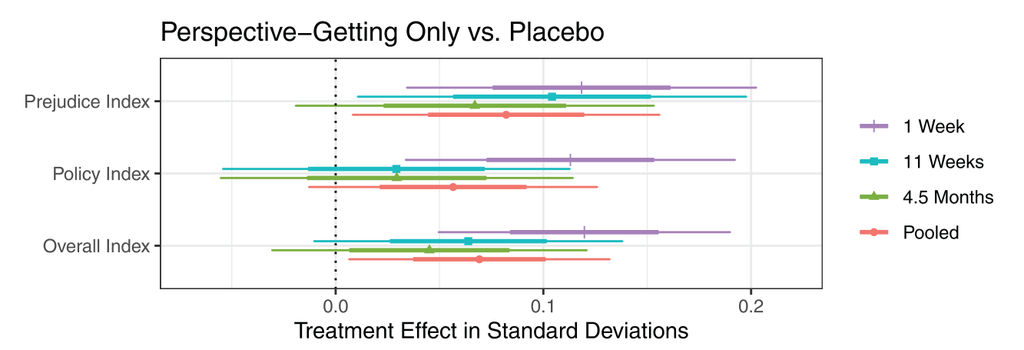

## Findings on: Perspective-getting

**Kalla & Broockman (2023, Fig. 7):** perspective-getting (esp. active) ↑ inclusion across different out-groups

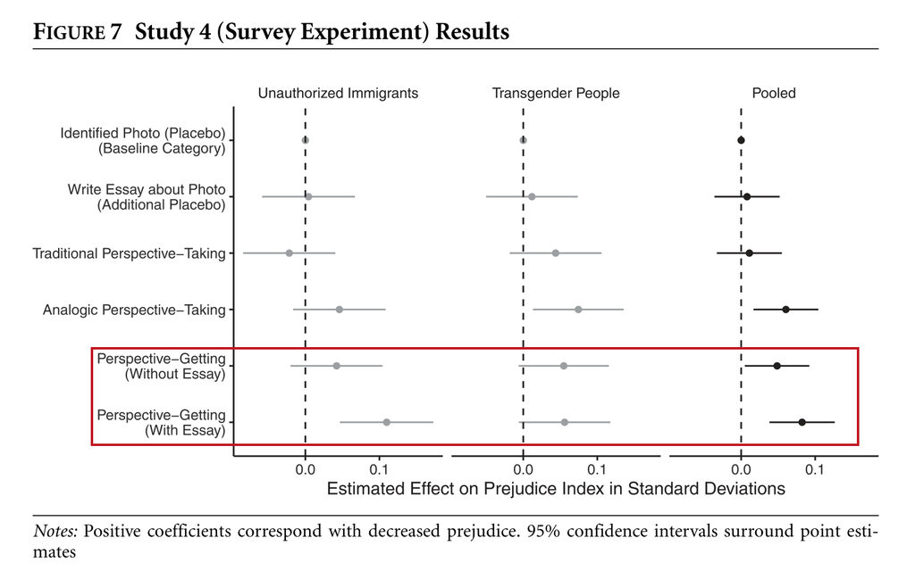

## Vicarious perspective-giving

**Strategy (Kalla & Broockman 2023):** Ask to recount the experiences of an outgroup member.

Uncle Seán *cuts into turkey, takes a sip of wine*  
You know, I was reading something the other day about the hospital waiting lists — absolute nightmare now. And half of it, honestly, is just the pressure from… well, people coming in who haven't paid in, haven't they? I mean, I'm not saying don't help folk, but when your own nan's waiting six months for a hip operation while we're processing asylum claims… it doesn't add up, does it?  
*glances up*  
How's your turkey? What do you reckon—you're studying all this stuff at uni now.

You Uncle Seán, leave the news aside for a second. Do you actually know anyone who came here as an immigrant or asylum seeker? Someone you've met, not in the papers? What was their experience like, as you remember it?

…

You What sticks with you from their experience, what was it like for them as you saw it?

…

You Can both that person and Nan's waiting list be true at once without one cancelling the other?

## Findings on: Vicarious perspective-giving

**Kalla & Broockman (2023, Fig. 5):** adding vicarious perspective-giving ≈ 0

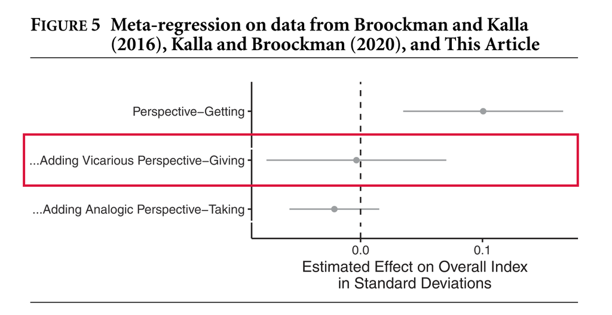

## Empathy-based counterspeech

**Strategy (Hangartner et al. 2021):** Invite to consider how exclusionary claims feel for out-group members.

Uncle Seán *cuts into turkey, takes a sip of wine*  
You know, I was reading something the other day about the hospital waiting lists — absolute nightmare now. And half of it, honestly, is just the pressure from… well, people coming in who haven't paid in, haven't they? I mean, I'm not saying don't help folk, but when your own nan's waiting six months for a hip operation while we're processing asylum claims… it doesn't add up, does it?  
*glances up*  
How's your turkey? What do you reckon—you're studying all this stuff at uni now.

You Uncle Seán — before we go further, can we sit with how that lands? For someone who fled their home and is waiting on a decision here, hearing “you're why Nan's still waiting” is pretty crushing. What would it feel like to be talked about that way when you're already scared and far from everything you know?

…

## Findings on: Empathy-based counterspeech

**Hangartner et al. (2021, Fig. 2):** empathy ↓ xenophobic tweets / ↑ deletion

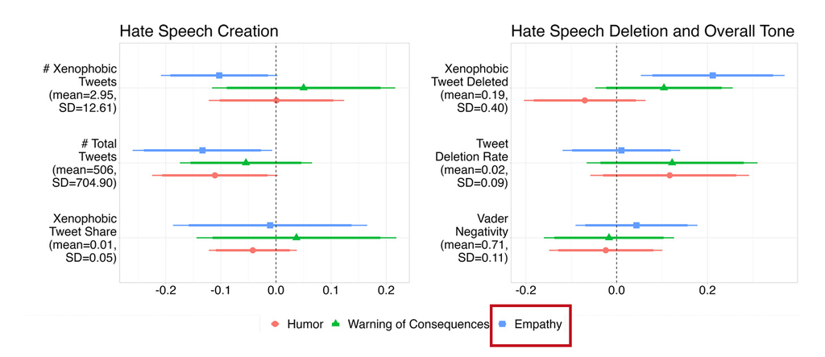

## Additional findings

**Messenger identity ≈ irrelevant** (Kalla & Broockman 2020; 2023)

- Holds for immigrant / non-immigrant, Latino / non-Latino, transgender / cisgender canvassers
  - Speaks against a pure intergroup-contact effect
  - Ethically reassuring, i.e., minority groups need not carry the double burden of enduring exclusion and doing persuasion labor
  - Works with little prior outreach experience (no veteran canvassers needed)

**Audience** *(Adida et al. 2018)*

- Traditional perspective-taking strongest among Democrats; smaller but positive among Republicans

**Mode / form** *(Kalla & Broockman 2020; 2023)*

- In-person, phone, and video all work
- Active perspective-getting (writing essay) > passive

**Durability** *(Adida et al. 2018; Broockman & Kalla 2016; Kalla & Broockman 2020)*

- Behavioral effects fade within a week
- Attitudinal effects last months + resist opposition ads

Open Questions/Critique

## Open Questions/Critique

- Implicit attitudes untested in persuasion field experiments (see Roman & Thompson (2024): D-score, straight bias, heterocentrism)?
- Does sequential use of different strategies work (e.g. empathy → narratives → belief correction) and does order matter?

With all you learned, have one more try with Uncle Seán

[figure not shown]

https://uncle-sean.onrender.com/

# Outlook

## Next week: policy + guest lecture

**Week 11** (Mon 23 / Wed 25 Nov): Policy and hate crime + guest lecture.

**Guest (Wed):** Dr. Tim Allinger — exclusionary policy and hate crimes (nomad camps in Italy).

**Required readings**

- Lehmann, M. C., & Masterson, D. T. (2020). Does aid reduce anti-refugee violence? Evidence from Syrian refugees in Lebanon. *American Political Science Review*, 114(4), 1335–1342.
- Levy, B. L., & Levy, D. L. (2017). When love meets hate: The relationship between state policies on gay and lesbian rights and hate crime incidence. *Social Science Research*, 61, 142–159.
- Allinger, T. L. (n.d.). Do exclusionary policies increase hate crimes? Evidence from the nomad camps in Italy. Working paper.
- Ankori-Karlinsky, L. O. (2026). Political symbols and social order: Confederate monuments and performative violence in the post-Reconstruction US South. *American Political Science Review*, 120(2), 681–706.

Weekly comments this week are on the **guest-lecture paper** and **may not be skipped**.